# Prediction of real MicroRNA Candidates using Machine Learning

Bo Zheng, Marius Rüve, Filip Mazug, Lukas Jansen

2019-03-18

# Einleitung

## Micro RNA

- Kleines, **nicht codierendes** RNA Molekül, welches man in Pflanzen, Tieren und Viren findet
- Ca. *22 Nukleotide* groß
- Lagert sich an komplementäre messenger RNA: **posttranskriptionale Regulation der Genexpression**
- Verhindert die Anlagerung an die Ribosomen: **keine Proteinbiosynthese**

(Ng and Mishra 2007)

## Motivation

- Micro RNAs (**miRNA**) als Kern von Biochips
  - Vorhersage von Lungenkrebs und MS! (Stähler 2010)
- Bestimmte miRNAs wirken **krebsfördernd** (oncomiRs) (Kooshapur et al. 2018)
- Problem: Erkennung von *echten* pre-miRNA Kandidaten
- Ziel: Ein Klassifikationsmodell für die pre-miRNA Kandidaten zu erstellen und **sinnvolle** Features auszuwählen

## Machine Learning

- Anwendung von künstlicher Intelligenz
  - Möglichkeit des **Lernens** anhand von Testdaten
- Verschiedene Machine Learning (ML) Methoden:
  - *Supervised ML*:
    - Alle Zielwerte der Daten eines Testdatensatzes sind gegeben und der Algorithmus lernt anhand dieser die Struktur
  - *Unsupervised ML*:
    - Hier sind die Ergebnisse für die Testdaten nicht gegeben und der Algorithmus muss selber eine Strukturierung erkennen, mit der er neue Daten bewerten kann

# Projektphasen

## GitHub

[figure not shown]

https://github.com/OstfriesenBI/PredmiRNA

- Öffentliche einsehbare Git Repositories(Repos)
- Web GUI, Issue Tracker, Team Collaboration etc.
- GitHub Profil als Portofolio eines Entwicklers
- Reproduktion: `git clone` & `snakemake --use-conda report`

## Phase 1 - Done

- Vorbereitung der Features
  - Inhalt/Aussage der einzelnen Features
  - Verstehen der Berechnung
  - Planung des Outputs
  - Existierende Programme
- Schreiben der einzelnen Skripte für die Features

## Phase 2 - (almost) Done

- Einbindung der Skripte in den Workflow (Snakemake)
  - Sequenzen -> Ergebnisse der einzelnen Features
- Visualisierung der Daten

## Phase 3 - WIP

# Feature Beispiele

## Was ist ein Feature?

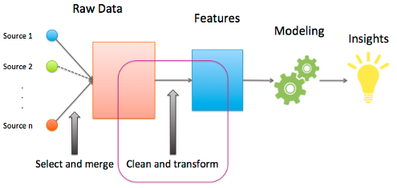

(Alice Zheng 2018)

- Ein **Feature** ist eine Eigenschaft einer Datenausprägung
- Die Verknüpfung von vielen **sinnvollen** Features ist notwendig um auf ein gutes Ergebnis mit ML zu kommen
- Verringerung der Daten auf wenige leichter handhabbare Features um besser mit ihnen weiter arbeiten zu können

## Minimum Free Energy

- Stabilste Sekundärstruktur nach dem Algorithmus von Zuker -> geringstes Energieniveau
- Funktionsweise: Aufsummierung der negativen Basenstapelkräfte
- Nicht unbedingt die in-vivo Struktur
- Reprästiert als “Dot-Bracket notation”

(ViennaRNA Hofacker 2003)

## Beispiel Faltung hsa-mir-19a

```
GCAGUCCUCUGUUAGUUUUGCAUA
GUUGCACUACAAGAAGAAUGUAGU
UGUGCAAAUCUAUGCAAAACUGAU
GGUGGCCUGC
```

Wird zu

```
((((.((.((((((((((((((((((((
(((((((.......))))...)))))).
.))))))))))))))))).)).))))
```

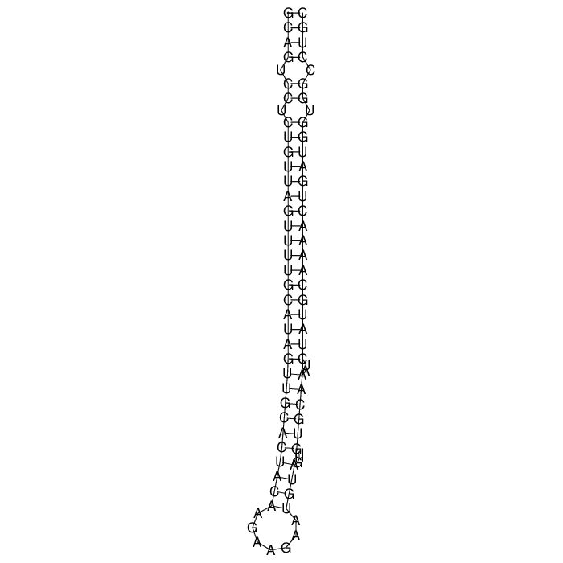

hsa-mir-19a

## Dichteverteilung der MFE

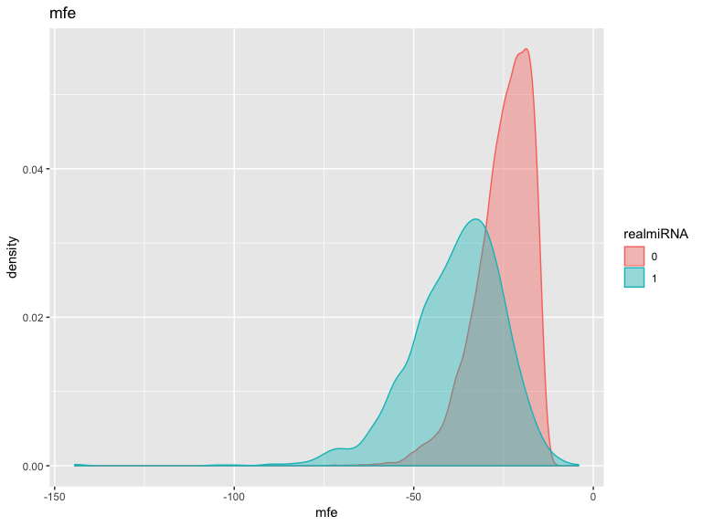

## Dichteverteilung der MFEI1

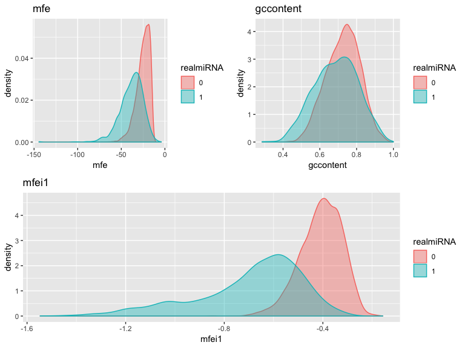

# Verwendete Tools

## Conda

[figure not shown]

- Problem in der Bioinformatik: Viele Tools, die von verschiedenen Libraries/anderen Tools abhängen
- Conda ist ein Packagemanager vergleichbar wie apt
- Unabhängig von dem Systempfaden verwendbar

## Python

[figure not shown]

- Intepretierte, High-Level, Allzweck-Programmiersprache
- Readability
- Genutzt für: Web development, software development, scientific computing
- Einfache Syntax ähnlich zur englischen Sprache
- Aktuell wichtige Rolle in Data Science und Bioinformatik

## R

[figure not shown]

- Programmiersprache und kostenlose Software Enviroment für statistische Berechnungen und Grafiken
- Wird benutzt von Statistikern und Data Minern um Software für Daten Analysen zu entwickeln

## Snakemake

[figure not shown]

- Snakemake ist ein auf Python basierendes Workflow-Management-Tool
- Ein Workflow beinhaltet einen Satz an Regeln
- Eine Regel ist eine Beschreibung, wie aus Input-Files Output-Files zu erzeugen sind
- Dadurch können Ergebnisse von einem Programm an ein anderes weitergegeben werden

(Köster and Rahmann 2018)

## WeKa

- Sammlung von ML Algorithmen für Data Mining Augaben
- Die Algorithmen können entweder direkt auf die Daten angewendet werden oder in einem Java Programm aufgrufen
- Weka beinhaltet Tools zur Daten-Vorbereitung, Klassifizierung, Regression, Clustering und Visualisierung

(Hall et al. 2009)

# Anhang

## Beispiel Regeln

```python
rule fold:
    input:
        basedir+"/{inputgroup}/split/{inputgroup}.fasta_chunk_{index}"
    output:
        basedir+"/{inputgroup}/fold/{index}.fold"
    shadow:
        "shallow" # Run it in an isolated enviroment
    conda: "envs/rnafold.yaml"
    shell:
        "RNAfold --noPS -p < {input} > {output}"
rule parsernafold:
    input:
        rules.fold.output
    output:
        basedir+"/{inputgroup}/datasplit/{index}.fold.csv"
    script:
        "scripts/rnafold2csv/rnafold2csv.py"
```

## Snakemake Workflow

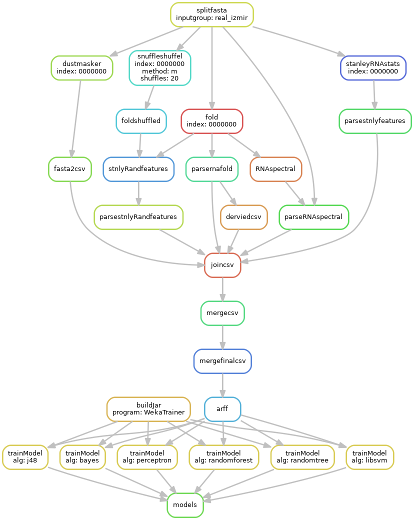

Der aktuelle Workflow

## Literatur 1

Hall, Mark, Eibe Frank, Geoffrey Holmes, Bernhard Pfahringer, Peter Reutemann, and Ian H. Witten. 2009. “The WEKA Data Mining Software.” ACM SIGKDD Explorations Newsletter 11 (1): 10. https://doi.org/10.1145/1656274.1656278. Hofacker, I. L. 2003. “Vienna RNA Secondary Structure Server.” Nucleic Acids Research 31 (13): 3429–31. https://doi.org/10.1093/nar/gkg599.

Kooshapur, Hamed, Nila Roy Choudhury, Bernd Simon, Max Mühlbauer, Alexander Jussupow, Noemi Fernandez, Alisha N. Jones, et al. 2018. “Structural Basis for Terminal Loop Recognition and Stimulation of Pri-miRNA-18a Processing by hnRNP A1.” Nature Communications 9 (1). https://doi.org/10.1038/s41467-018-04871-9.

## Literatur 2

Köster, Johannes, and Sven Rahmann. 2018. “Snakemake—a scalable bioinformatics workflow engine.” Bioinformatics 34 (20): 3600–3600. https://doi.org/10.1093/bioinformatics/bty350.

Ng, Kwang Loong Stanley, and Santosh K. Mishra. 2007. “De novo SVM classification of precursor microRNAs from genomic pseudo hairpins using global and intrinsic folding measures.” Bioinformatics 23 (11): 1321–30. https://doi.org/10.1093/bioinformatics/btm026.

## Literatur 3

Stähler, Peer. 2010. “Molekulare Diagnoseverfahren: miRNA-Biomarker im Blut.” Dtsch Arztebl International 107 (10): A–454 –. http://www.aerzteblatt.de/int/article.asp?id=68103.

Alice Zheng, Amanda Casari. 2018. *Feature Engineering for Machine Learning - Principles and Techniques for Data Scientists*. Sebastopol: "O’Reilly Media, Inc.".

Hall, Mark, Eibe Frank, Geoffrey Holmes, Bernhard Pfahringer, Peter Reutemann, and Ian H. Witten. 2009. “The WEKA Data Mining Software.” *ACM SIGKDD Explorations Newsletter* 11 (1): 10. https://doi.org/10.1145/1656274.1656278.

Hofacker, I. L. 2003. “Vienna RNA Secondary Structure Server.” *Nucleic Acids Research* 31 (13): 3429–31. https://doi.org/10.1093/nar/gkg599.

Kooshapur, Hamed, Nila Roy Choudhury, Bernd Simon, Max Mühlbauer, Alexander Jussupow, Noemi Fernandez, Alisha N. Jones, et al. 2018. “Structural Basis for Terminal Loop Recognition and Stimulation of Pri-miRNA-18a Processing by hnRNP A1.” *Nature Communications* 9 (1). https://doi.org/10.1038/s41467-018-04871-9.

Köster, Johannes, and Sven Rahmann. 2018. “Snakemake—a scalable bioinformatics workflow engine.” *Bioinformatics* 34 (20): 3600–3600. https://doi.org/10.1093/bioinformatics/bty350.

Ng, Kwang Loong Stanley, and Santosh K. Mishra. 2007. “De novo SVM classification of precursor microRNAs from genomic pseudo hairpins using global and intrinsic folding measures.” *Bioinformatics* 23 (11): 1321–30. https://doi.org/10.1093/bioinformatics/btm026.

Stähler, Peer. 2010. “Molekulare Diagnoseverfahren: miRNA-Biomarker im Blut.” *Dtsch Arztebl International* 107 (10): A–454 –. http://www.aerzteblatt.de/int/article.asp?id=68103.